**Probability for Machine Learning**

Table of Contents

# 1. Random Variable

## 1.1. Definition

A **random variable** is a numerical quantity whose value is determined by the outcome of a random process. It serves as a mathematical representation of uncertainty.

Formally, a random variable $x$ is associated with a probability distribution, which specifies the likelihood that $x$ takes on specific values.

For a random variable $x$, the probability that it takes the value $a$ is written as:

$$ P(x = a) \;\triangleq\; P_X(x = a) $$

The following conditions must be satisfied:

$$ \begin{cases} 1)\; P(x = a) \geq 0 \quad \text{for all } a \in \mathcal{X} \\ 2)\; \sum\limits_{\text{all } x} P(x) = 1 \quad \text{(for discrete r.v.)} \end{cases} $$

In the case of continuous random variables, the summation is replaced by integration:

$$ \int_{-\infty}^{\infty} P(x)\,dx = 1 $$

**Types of Random Variables**

Random variables can be classified into two categories:

- Discrete random variable takes values from a countable set
- Continuous random variable takes values from a continuous range

Examples:

- Tossing a coin: discrete r.v. with outcomes ${0, 1}$
- Measuring temperature: continuous r.v. over $\mathbb{R}$

The choice of modeling a quantity as discrete or continuous depends on the nature of the data and the resolution at which the random process is observed.

**Example**

Let $x$ be the outcome of a fair die:

$$P(x = 1) = P(x = 2) = \dotsb = P(x = 6) = \frac{1}{6}$$

**Example**

Let $y = x_1 + x_2$: the sum of two independent dice rolls.

What is the probability that $y = 5$?

$$P_Y(y = 5) = \;?$$

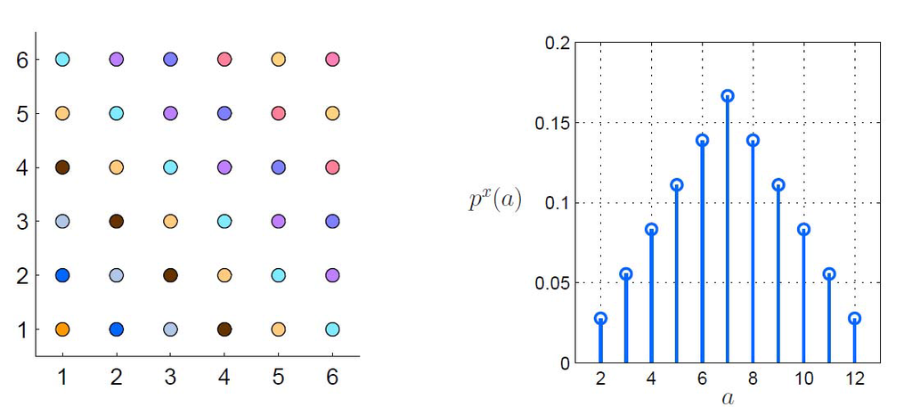

## 1.2. Expectation (= Mean)

The expectation (or mean) of a random variable is a measure of its central tendency. It represents the long-run average value of the variable if the random process is repeated many times.

The expectation of a random variable $x$ is defined as:

$$ E[x] = \begin{cases} \sum\limits_{x} x \cdot P(x) & \text{(for discrete random variables)} \\\\ \int x \cdot P(x) \, dx & \text{(for continuous random variables)} \end{cases} $$

The expectation is a weighted average, where the weights are given by the probability distribution of the random variable.

**Example: Uniform Distribution**

Suppose $x$ takes on $m$ equally likely values (i.e., a uniform distribution), so that:

$$P(x) = \frac{1}{m}$$

Then the expectation becomes:

$$E[x] = \sum\limits_{x} x \cdot \frac{1}{m} = \frac{1}{m} \sum_x x$$

The variance of a random variable $x$ is defined as the expected squared deviation from its mean:

$$\mathrm{Var}[x] = E\left[ \left(x - E[x] \right)^2 \right]$$

This quantifies the spread or uncertainty of the random variable around its mean.

# 2. Random Vectors (Multivariate R.V.)

A **random vector** is a collection of multiple random variables:

$$ x = \begin{bmatrix} x_1 \\ x_2 \\ \vdots \\ x_n \end{bmatrix}, \quad \text{where each } x_i \text{ is a random variable} $$

## 2.1. Joint Probability Density

The **joint probability density** (or mass) function models the probability of co-occurrence of multiple random variables:

$$P_{X_1, \cdots, X_n}(X_1 = x_1, \cdots, X_n = x_n)$$

This represents the probability that all $n$ random variables take on specific values simultaneously.

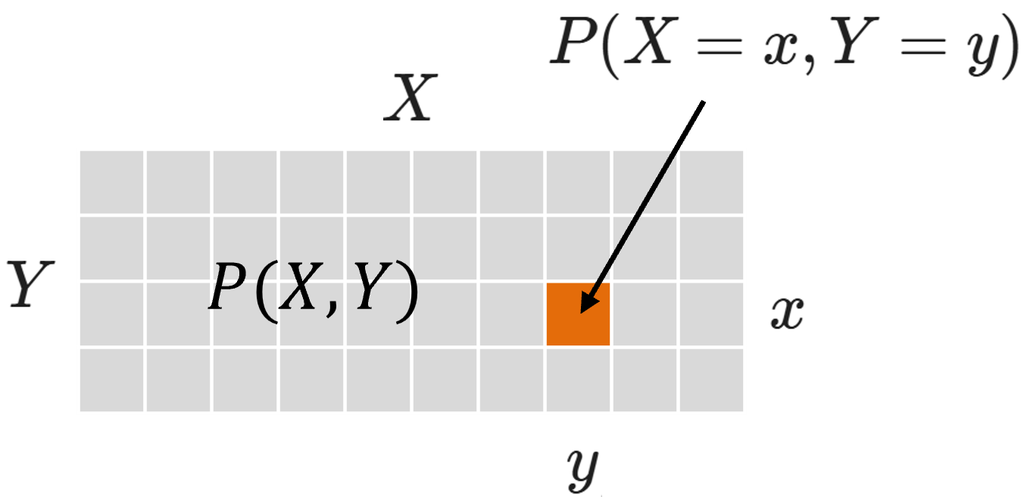

For the continuous case, a **joint probability density function** $p(x_1, \dotsc, x_n)$ is defined such that:

$$ P(a_1 \leq X_1 \leq b_1, \cdots, a_n \leq X_n \leq b_n) = \int_{a_1}^{b_1} \dotsm \int_{a_n}^{b_n} p(x_1, \cdots, x_n) \, dx_n \dotsm dx_1 $$

## 2.2. Marginal Density (or Marginal Probability)

The marginal probability describes the probability distribution of a subset of variables from a joint distribution. It is obtained by summing (discrete case) or integrating (continuous case) over the other variables.

For a random vector:

$$x = \begin{bmatrix}x_1 \\ x_2 \\ \vdots \\ x_n\end{bmatrix}$$

The marginal distribution of each component is:

$$ \begin{align*} P_{X_1}(X_1 &= x_1) = \text{probability distribution of } X_1 \\\\ P_{X_2}(X_2 &= x_2) = \text{probability distribution of } X_2 \\\\ &\vdots \\\\ P_{X_n}(X_n &= x_n) = \text{probability distribution of } X_n \end{align*} $$

**Two Random Variables**

Suppose we have two random variables $X$ and $Y$ with joint distribution $P(X, Y)$.

Discrete Case

$$ \begin{align*} P(X) &= \sum_y P(X, Y = y) \\\\ P(Y) &= \sum_x P(X = x, Y) \end{align*} $$

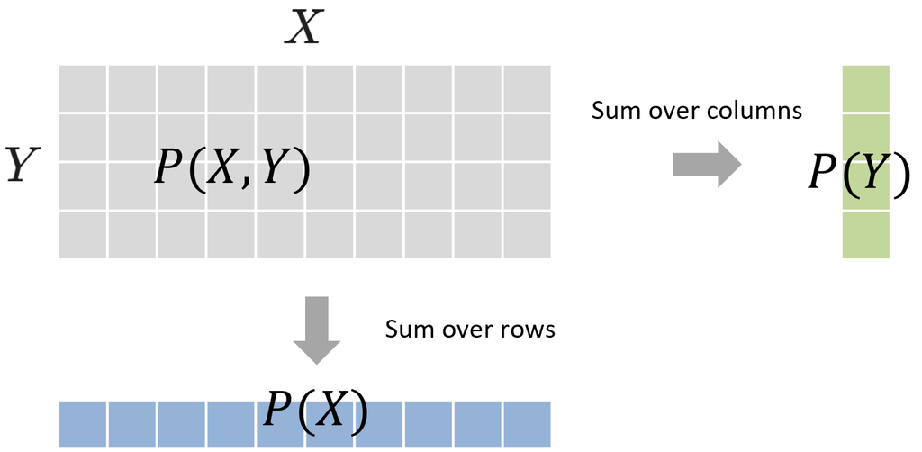

Continuous Case

$$ \begin{align*} p_X(x) &= \int p(x, y) \, dy \\\\ p_Y(y) &= \int p(x, y) \, dx \end{align*} $$

The marginal probability isolates the distribution of one variable regardless of the others. It is essential for understanding individual variables in multivariate settings.

## 2.3. Conditional Probability

The **conditional probability** measures the likelihood of a random variable taking a particular value, *given* that another variable is already known to take a specific value.

Formally, the conditional probability of $X_1 = x_1$ given $X_2 = x_2$ is defined as:

$$ P_{X_1 \mid X_2}(X_1 = x_1 \mid X_2 = x_2) = \frac{P(X_1 = x_1,\; X_2 = x_2)}{P(X_2 = x_2)} $$

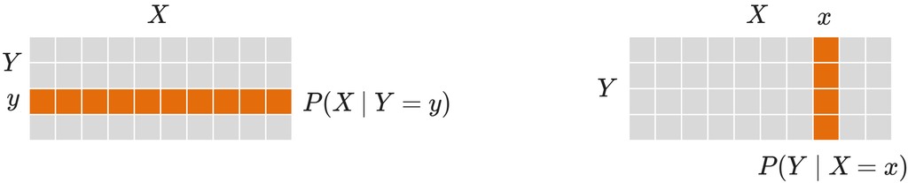

**Independence**

Two random variables $X_1$ and $X_2$ are **independent** if the outcome of one provides no information about the outcome of the other.

This is equivalent to any of the following conditions:

$$ \begin{align*} P(X_1 = x_1 \mid X_2 = x_2) &= P(X_1 = x_1) \\\\ \Updownarrow \\\\ P(X_2 = x_2 \mid X_1 = x_1) &= P(X_2 = x_2) \\\\ \Updownarrow \\\\ P(X_1 = x_1,\; X_2 = x_2) &= P(X_1 = x_1) \cdot P(X_2 = x_2) \end{align*} $$

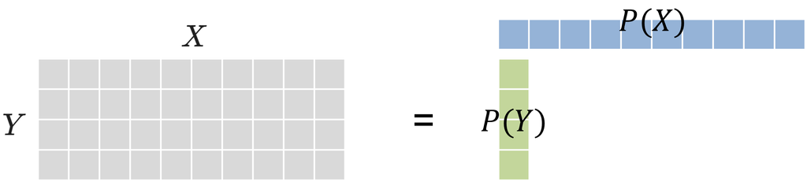

Independence simplifies many probabilistic models and is a common assumption in both theory and practice.

**Example: Dice**

Let $\omega_1, \omega_2, \omega_3, \omega_4$ be outcomes of four independent dice.

$$ \begin{align*} x &= \omega_1 + \omega_2 \quad \text{(sum of the first two dice)} \\\\ y &= \omega_1 + \omega_2 + \omega_3 + \omega_4 \quad \text{(sum of all four dice)} \end{align*} $$

(1) What is the joint probability?

$$ P\left( \begin{bmatrix}x \\ y\end{bmatrix} = \begin{bmatrix} a \\ b \end{bmatrix} \right) = P_X(x = a) \cdot P_{Y \mid X}(y = b \mid x = a) $$

(2) Marginal probability?

$$ P_X(x) = \sum_y P_{XY}(x, y) $$

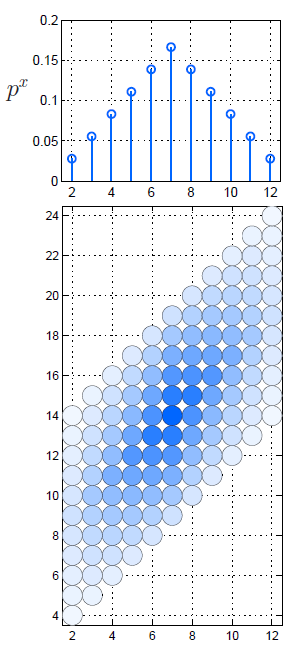

(3) Conditional Probability?

Suppose we observed $y = 19$, then:

$$P_{X \mid Y}(x \mid y = 19) = \frac{P_{XY}(x, y = 19)}{P_Y(y = 19)}$$

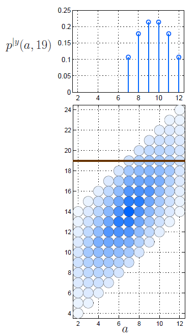

**Summary: Pictorial Illustrations**

- Probability
- Marginal Probability
- Conditional Probability

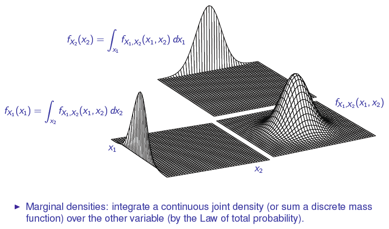

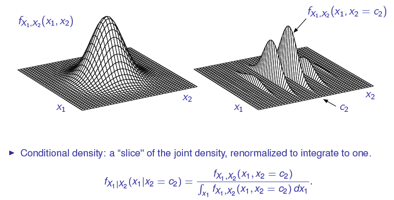

**Illustrative Example: Bins and Balls**

- There are 3 bins: A, B, C
- Two bins contain only white balls, one contains only black balls.

(1) What is the probability of drawing a white ball first? (White = 1)

$$ P(X_1 = 1) = \frac{2}{3} $$

(2) Given that a white ball was drawn first, what is the probability of drawing a white ball again from a different bin?

$$P(X_2 = 1 \mid X_1 = 1) = \frac{1}{2}$$

(3) What is the probability of drawing two white balls from two different bins?

$$ \begin{align*} P(X_1 = 1, X_2 = 1) &= P(X_2 = 1 \mid X_1 = 1) \cdot P(X_1 = 1) \\\\ &= \frac{1}{2} \cdot \frac{2}{3} = \frac{1}{3} \end{align*} $$

# 3. Bayes Rule

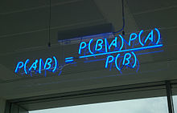

Bayes' rule allows us to reverse the conditioning in a probability statement. That is, it lets us compute $P(A \mid B)$ when we know $P(B \mid A)$ and the marginal probabilities.

The rule follows from the symmetry of the joint probability:

$$ \begin{align*} P(X_2, X_1) &= P(X_2 \mid X_1) \cdot P(X_1) = P(X_1 \mid X_2) \cdot P(X_2) \\\\ \therefore \quad P(X_{\color{red}2} \mid X_{\color{red}1}) &= \frac{P(X_{\color{red}1} \mid X_{\color{red}2}) \cdot P(X_2)}{P(X_1)} \end{align*} $$

**Example**

In a population:

- 40% are male (M), 60% are female (F)
- Among males, 50% are smokers (S);
- Among females, 30% are smokers

Question: What is the probability that a randomly selected smoker is male?

Let:

$$ x = \text{M or F}, \qquad y = \text{S or N} $$

Given:

$$ \begin{align*} P(x = \text{M}) &= 0.4 \\ P(x = \text{F}) &= 0.6 \\ P(y = \text{S} \mid x = \text{M}) &= 0.5 \\ P(y = \text{S} \mid x = \text{F}) &= 0.3 \end{align*} $$

We want to compute:

$$ P(x = \text{M} \mid y = \text{S}) = \; ? $$

Apply Bayes' rule

$$ \begin{align*} P(x = \text{M} \mid y = \text{S}) &= \frac{P(y = \text{S} \mid x = \text{M}) \cdot P(x = \text{M})}{P(y = \text{S})} \\\\ &= \frac{0.5 \cdot 0.4}{P(y = \text{S})} = \frac{0.20}{0.38} \approx 0.53 \end{align*} $$

Compute the denominator

$$ \begin{align*} P(y = \text{S}) &= P(y = \text{S} \mid x = \text{M}) \cdot P(x = \text{M}) + P(y = \text{S} \mid x = \text{F}) \cdot P(x = \text{F}) \\\\ &= 0.5 \cdot 0.4 + 0.3 \cdot 0.6 = 0.20 + 0.18 = 0.38 \end{align*} $$

Thus, the probability that a smoker is male is approximately 53%.

# 4. Linear Transformation of Random Variables

## 4.1. Single Random Variable

Consider a linear transformation of a scalar random variable $X$:

$$Y = aX$$

**Expectation**

The expectation of $Y$ is:

$$ E[aX] = aE[X] $$

This result follows from the linearity of expectation.

**Variance**

The variance of $Y$ is:

$$ \text{Var}(aX) = a^2 \cdot \text{Var}(X) $$

The constant $a$ scales the variance quadratically.

**Derivation of Variance Formula**

Let $\bar{X} = E[X]$ be the mean of $X$. Then the variance of $X$ is:

$$ \begin{align*} \text{Var}(X) &= E\left[(X - \bar{X})^2\right] \\ &= E[X^2 - 2X\bar{X} + \bar{X}^2] \\ &= E[X^2] - 2\bar{X}E[X] + \bar{X}^2 \\ &= {E}[X^2] - 2 \bar{X}^2 + \bar{X}^2\\ &= {E}[X^2] - \bar{X}^2 \\ &= E[X^2] - E[X]^2 \end{align*} $$

This identity is fundamental in probability theory and appears frequently in statistical analysis.

## 4.2. Sum of Two Random Variables

Let $Z$ be the sum of two scalar random variables:

$$Z = X + Y \quad \text{(still a scalar r.v.)}$$

**Expectation**

The expectation of the sum is simply the sum of the expectations:

$$E[X + Y] = E[X] + E[Y]$$

**Variance**

The variance of the sum is:

$$ \begin{align*} \text{Var}(X + Y) &= E[(X + Y - E[X + Y])^2] \\ &= E[((X - \bar{X}) + (Y - \bar{Y}))^2] \\ &= E[(X - \bar{X})^2] + E[(Y - \bar{Y})^2] + 2E[(X - \bar{X})(Y - \bar{Y})] \\ &= \text{Var}(X) + \text{Var}(Y) + 2\cdot\text{Cov}(X, Y) \end{align*} $$

If $X$ and $Y$ are independent, then $\text{Cov}(X, Y) = 0$, and the variance simplifies to:

$$ \text{Var}(X + Y) = \text{Var}(X) + \text{Var}(Y) $$

**Covariance**

The covariance of two random variables measures their linear dependence:

$$ \begin{align*} \text{Cov}(X, Y) &= E[(X - \bar{X})(Y - \bar{Y})] \\ &= E[XY] - E[X]E[Y] \end{align*} $$

If $X$ and $Y$ are independent, their covariance is zero.

**Practical Note**

In quality control applications, the total variance of a product assembled from multiple components is affected not only by the precision of each component but also by the correlation between them.

Suppose a factory uses two machines, A and B, connected in series. Machine A produces an intermediate part with variance $\text{Var}(X)$, and machine B finishes the product with variance $\text{Var}(Y)$. The final product is assembled from outputs of both machines, so its total variance is:

$$ \text{Var}(X + Y) = \text{Var}(X) + \text{Var}(Y) + 2 \cdot \text{Cov}(X, Y) $$

If we assume $X$ and $Y$ are independent, the covariance term disappears, and the only way to reduce the total variance is by improving the precision (i.e., reducing $\text{Var}(X)$ and $\text{Var}(Y)$) of each machine. This often means redesigning hardware or using tighter tolerances, which can be expensive.

However, there is another approach from a system engineering perspective: introduce a negative correlation between $X$ and $Y$. If $\text{Cov}(X, Y) < 0$, it can *reduce* the total variance, even if the individual variances remain unchanged.

This insight is useful because designing components that compensate for each other's errors is often more cost-effective than increasing the precision of each part in isolation. Rather than treating correlation as a drawback, we can exploit it for system-level benefits.

Remark:

- Variance applies to a single variable
- Covariance applies to pairs of variables

**Covariance Matrix for Random Vectors**

For a random vector $X = \begin{bmatrix} X_1 \\ X_2 \end{bmatrix}$ with mean vector $\mu = E[X]$:

$$ \text{Cov}(X) = E[(X - \mu)(X - \mu)^T] = \begin{bmatrix} \text{Var}(X_1) & \text{Cov}(X_1, X_2) \\ \text{Cov}(X_2, X_1) & \text{Var}(X_2) \end{bmatrix} $$

This symmetric matrix captures both the spread (variances) and correlation (covariances) of the components.

## 4.3. Affine Transformation of Random Vectors

Let a random vector $x \in \mathbb{R}^n$ be transformed via an affine map:

$$ y = Ax + b $$

Then the expectation and covariance of the transformed vector $y$ are given by:

Expectation:

$$ E[y] = A E[x] + b $$

Covariance:

$$ \text{Cov}(y) = A \cdot \text{Cov}(x) \cdot A^T $$

These results follow from the linearity of expectation and properties of covariance under linear transformations.

**IID Random Variables**

Suppose $x_1, \cdots, x_m$ are independent and identically distributed (IID) random variables with:

$$ E[x_i] = \mu, \quad \text{Var}(x_i) = \sigma^2 $$

Define the vector:

$$ x = \begin{bmatrix} x_1 \\ \vdots \\ x_m \end{bmatrix} $$

Then:

$$ E[x] = \begin{bmatrix} \mu \\ \vdots \\ \mu \end{bmatrix}, \quad \text{Cov}(x) = \begin{bmatrix} \sigma^2 & & &\\ & \sigma^2 & &\\ & & \ddots &\\ & & & \sigma^2 \end{bmatrix} = \sigma^2 I_m $$

**Sample Mean as Linear Combination**

The sample mean is:

$$ S_m = \frac{1}{m} \sum_{i=1}^m x_i = A x, \quad \text{where } A = \frac{1}{m} \begin{bmatrix} 1 & \cdots & 1 \end{bmatrix} $$

Then:

$$ \begin{align*} E[S_m] &= A E[x] = \mu \\\\ \text{Var}(S_m) &= A \cdot \text{Cov}(x) \cdot A^T = \frac{\sigma^2}{m} \end{align*} $$

This result confirms that **averaging reduces variance**.

**Central Limit Approximation**

For large $m$, the sample mean $\bar{x}$ approaches a normal distribution:

$$ \bar{x} = \frac{1}{m} \sum_{i=1}^m x_i \;\; \longrightarrow \;\; N\left(\mu,\; \left(\frac{\sigma}{\sqrt{m}}\right)^2 \right) $$

This approximation is a cornerstone of statistical inference, formalized by the Central Limit Theorem.

- The more samples we take, the more concentrated the mean becomes around the true expectation
- The variance of the mean decreases at a rate of $1/m$

```python
%%javascript
$.getScript('https://kmahelona.github.io/ipython_notebook_goodies/ipython_notebook_toc.js')
```